# Part II - (Communicate Data Findings)

by **(Chidozie Ahamefule)**

## Investigation Overview

> In this investigation I wanted to figure out two things:

The greatest aim and concern for Loan companies like Prosper, would be to give out loans to the right entities that would be able to pay back in good time.

Our main features would therefore be to be able to successfully predict and determine individuals/entities that would NOT default on their loan repayments schedule.

## Dataset Overview

> The Prosper loan dataset contains information on peer to peer loans facilitated by a credit company 'Prosper'. Our original dataset comprises of 113,937 rows of data & 81 columns.

Visualization 1

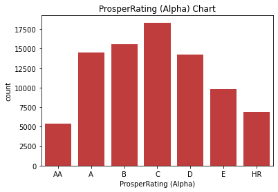

Observations

1. According to the ratings as stipulated in the Prosper company data dictionary, (0 - N/A, 1 - HR, 2 - E, 3 - D, 4 - C, 5 - B, 6 - A, 7 - AA), 7 - AA is the highest possible rating. From the univariate barchat above, ONLY about 5,000 Prosper customers fall into this category out of a possible 90,000.
2. Also, the most frequent Prosper rating is the 'C' alphabet.

(Visualization 2)

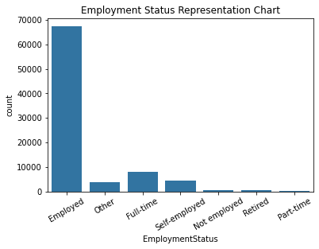

Observation

A vast majority of Prosper Loanees are 'Employed'. This is a good sign.

(Visualization 3)

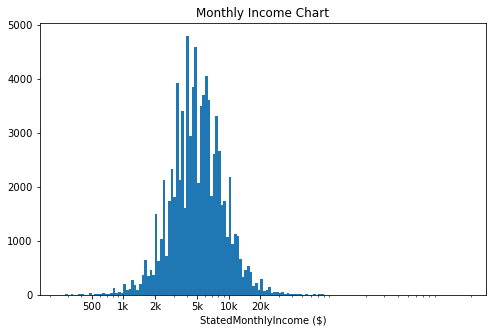

Visualization 4

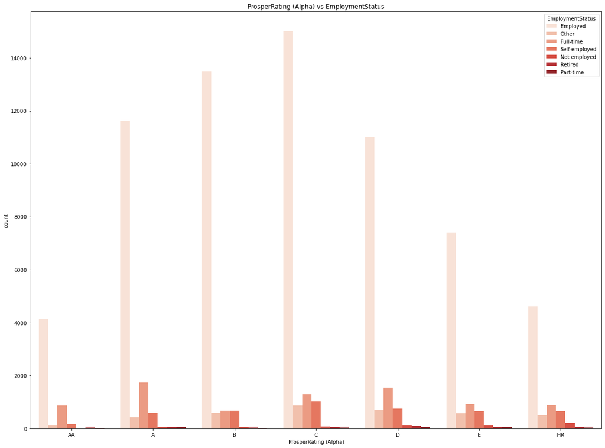